# Consequences of Covid-19 for Candle Critiques

Han Lee

3/29/2021

For this assignment, you will produce a report exploring the impact of Covid-19 on scented candle ratings.

Write this assignment like a report. You should describe the dataset, show appropriate plots, and interpret them. Remove the instruction text from this document.

In your report, fold the code blocks, enable code highlighting, and set an HTML theme of your choice. Set other document options as you prefer and as appropriate.

## The data

You will work with two datasets `Scented_all.xlsx` and `Unscented_all.xlsx`. Each dataset contains the following information for the Top 3 selling scented or unscented candles sold on Amazon:

1. `CandleID`: A numeric id variable for candle 1-3 in each category.
2. `Date`: The date of the review.
3. `Rating`: The 1-5 rating for the review.
4. `Review`: For the scented candles, the text of the review.

## HW05 Questions & Answers

### Part 1

```r
#Part 1 Instructions

#For each category of candle (scented versus unscented), for all days from **2017-01-01** onward, create a plot showing:

#  1. Date on the x axis
#    1. Hint: use `scale_x_date()`
#    2. Format the date labels as `"%m-%Y"`
#    3. Set the date breaks to be "6 months"
#  2. **Average daily rating** of each candle on the y axis
#  3. A smooth trend line (not linear; `method = "loess"`)
#  4. A dashed vertical line at January 01, 2020
#    1. Hint: use `geom_vline()` and set `xintercept = as.numeric(as.Date("2020-01-20"))`

#Be sure to make the plots beautiful.

#  1. Address overplotting of points using transparency or shapes.
#  2. Use an appealing theme and color scheme.
#  3. Set appropriately formatted axis titles and main plot title.
#  4. Place the two plots side by side.

#Note: The raw data are **individual reviews** so you will need to compute summary results to get average daily ratings for the desired date range.

#Interpret these graphs. What do they show about scented candles over the time period?
```

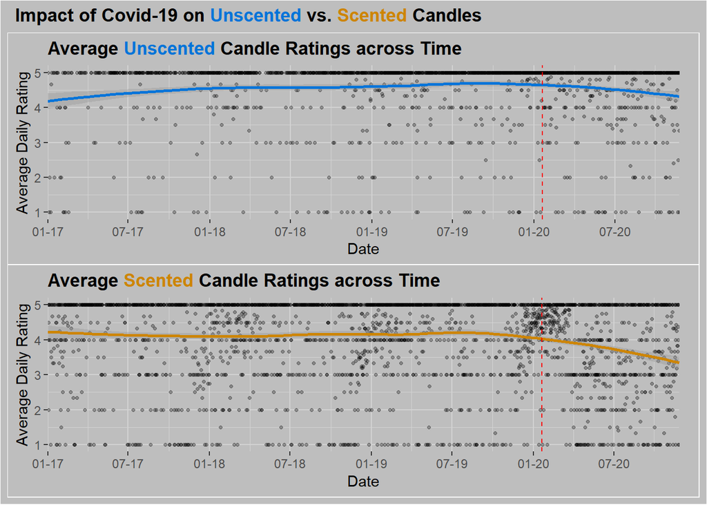

```r
#Uploading scented data
dat.scented <- read_csv(here::here("Scented_all.csv"),
                        col_types=cols(
                          CandleID = col_character(),
                          Date = col_character(),
                          Rating = col_double(),
                          Review = col_character()
                          )
                        )

#Adjust scented date data to correct format
dat.scented$Date = as.Date(dat.scented$Date, "%d-%b-%y")

#Filter scented data to dates after 2016 and ID below 4
cleaned.scented <- dat.scented %>%
  filter(Date >= as.Date("2017-01-01") & CandleID <= 3)

#Summarize ratings by ID and Date
mean.scented <- cleaned.scented %>%
  group_by (CandleID,
            Date
            ) %>%
  summarize(across(c(Rating),
                     list(Mu = ~ mean(.x,
                                      na.rm = TRUE
                                     ),
                         Sigma = ~ sd(.x,
                                      na.rm = TRUE
                                     ),
                         n = ~ n()
                         )
                  )
            )

#Plot
plot.scented <- ggplot(mean.scented) +
  aes(x=Date,
      y=Rating_Mu
      ) +
   scale_x_date(date_breaks = "6 months",
               date_labels = "%m-%y",
               expand = c(0,0),
               limits = c(min(mean.scented$Date),
                          max = max(mean.scented$Date)
                          )
               ) +
  scale_y_continuous(name = "Average Daily Rating") +
 geom_point(size = .9,
             alpha = .3
             ) +
  geom_smooth(method = "loess",
              colour = "orange3") +
  geom_vline(xintercept = as.numeric(as.Date("2020-01-20")),
             colour = "red",
             linetype = 2
             ) +
  ggtitle("Average Unscented Candle Ratings across Time") +
  theme(plot.background = element_rect(fill = "gray"),
        plot.title = element_markdown(face = "bold"),
        axis.text.x = element_text(size = 9),
        legend.position = "none",
        plot.margin = unit(c(.2, .5, .2, .2), "cm"),
        panel.background = element_rect(fill = "gray",
                                colour = "gray",
                                size = 0.5, linetype = "solid"),
        panel.grid.major = element_line(size = 0.5, linetype = 'solid',
                                colour = "lightgray"),
        panel.grid.minor = element_line(size = 0.25, linetype = 'solid',
                                colour = "lightgray")
        ) +
  labs(title = "Average <span style='color: orange3'>**Scented**</span>  Candle Ratings across Time")


#Uploading scented data
dat.unscented <- read_csv(here::here("Unscented_all.csv"),
                        col_types=cols(
                          CandleID = col_character(),
                          Date = col_character(),
                          Rating = col_double(),
                          Review = col_character()
                          )
                        )

#Adjust scented date data to correct format
dat.unscented$Date = as.Date(dat.unscented$Date, "%d-%b-%y")

#Filter scented data to dates after 2016 and ID below 4
cleaned.unscented <- dat.unscented %>%
  filter(Date >= as.Date("2017-01-01") & CandleID <= 3)

#Summarize ratings by ID and Date
mean.unscented <- cleaned.unscented %>%
  group_by (CandleID,
            Date
            ) %>%
  summarize(across(c(Rating),
                     list(Mu = ~ mean(.x,
                                      na.rm = TRUE
                                     ),
                         Sigma = ~ sd(.x,
                                      na.rm = TRUE
                                     ),
                         n = ~ n()
                         )
                  )
            )

#Plot
plot.unscented <- ggplot(mean.unscented) +
  aes(x = Date,
      y = Rating_Mu,
      ) +
  scale_x_date(date_breaks = "6 months",
               date_labels = "%m-%y",
               expand = c(0,0),
               limits = c(min(mean.unscented$Date),
                          max = max(mean.unscented$Date)
                          )
               ) +
  scale_y_continuous(name = "Average Daily Rating") +
  geom_point(size = .9,
             alpha = .3
             ) +
  geom_smooth(method = "loess",
              colour = "#0074D9") +
  geom_vline(xintercept = as.numeric(as.Date("2020-01-20")),
             colour = "red",
             linetype = 2
             ) +
  ggtitle("Average Unscented Candle Ratings across Time") +
  theme(plot.background = element_rect(fill = "gray"),
        plot.title = element_markdown(face = "bold"),
        axis.text.x = element_text(size = 9),
        legend.position = "none",
        plot.margin = unit(c(.2, .5, .2, .2), "cm"),
        panel.background = element_rect(fill = "gray",
                                colour = "gray",
                                size = 0.5, linetype = "solid"),
        panel.grid.major = element_line(size = 0.5, linetype = 'solid',
                                colour = "lightgray"),
        panel.grid.minor = element_line(size = 0.25, linetype = 'solid',
                                colour = "lightgray")
        ) +
  labs(title = "Average <span style='color: #0074D9'>**Unscented**</span>  Candle Ratings across Time")

plot.unscented + plot.scented +
  plot_layout(ncol = 1, guides = 'collect') +
  plot_annotation(title = "Impact of Covid-19 on <span style='color: #0074D9'>**Unscented**</span>  vs. <span style='color: orange3'>**Scented**</span> Candles",
                  theme = theme(plot.title = element_markdown(face = "bold"),
                                plot.background = element_rect(fill = "gray")
                                )
                  )
```

The graphs show that there is a general decreasing trend for both unscented and scented candles after 1-20-20. However the rate of decrease is larger for scented candles compared to unscented candles.

### Part 2

```r
#Part 2 Instructions:

#Combine the two datasets into one and make a plot similar to above, but showing both unscented and scented candles.
#Distinguish scented versus unscented candles using color, shape, and line type (for the trend lines).
#Which of these two sets of plots do you find easier to interpret?
```

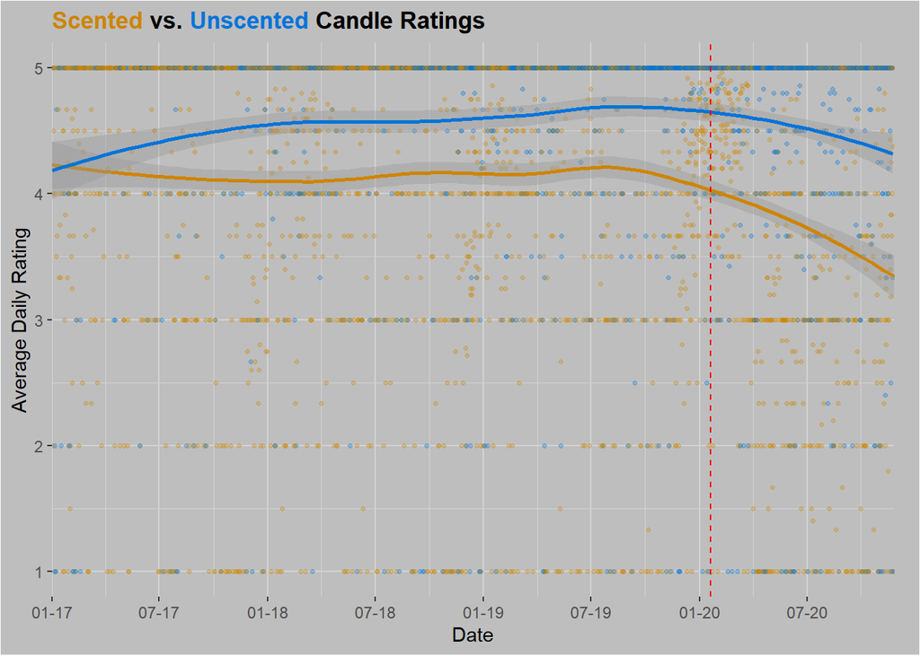

```r
#Combines the unscented and scented data set
cleaned.full <- bind_rows(
    scented = cleaned.scented,
    unscented = cleaned.unscented,
    .id = "Scented"
)

#Creates mean dataset of the combined dataset
mean.full = cleaned.full %>%
  group_by (CandleID,
            Date,
            Scented) %>%
  summarize(across(c(Rating),
                     list(Mu = ~ mean(.x,
                                      na.rm = TRUE
                                     ),
                         Sigma = ~ sd(.x,
                                      na.rm = TRUE
                                     ),
                         n = ~ n()
                         )
                  )
            )

#Plotting the mean dataset
plot.combined = ggplot(mean.full) +
  aes(x = Date,
      y = Rating_Mu,
      color = Scented
      ) +
  scale_x_date(date_breaks = "6 months",
               date_labels = "%m-%y",
               expand = c(0,0),
               limits = c(min(mean.full$Date),
                          max = max(mean.full$Date)
                          )
               ) +
  scale_y_continuous(name = "Average Daily Rating") +
  scale_color_manual(values = c("orange3", "#0074D9"),
                     aesthetics = c("color")
                     ) +
  geom_point(size = .9,
             alpha = .3
             ) +
  geom_smooth(method = "loess") +
  geom_vline(xintercept = as.numeric(as.Date("2020-01-20")),
             colour = "red",
             linetype = 2
             ) +
  theme(plot.background = element_rect(fill = "gray"),
        plot.title = element_markdown(face = "bold"),
        axis.text.x = element_text(size = 9),
        legend.position = "none",
        plot.margin = unit(c(.2, .5, .2, .2), "cm"),
        panel.background = element_rect(fill = "gray",
                                colour = "gray",
                                size = 0.5, linetype = "solid"),
        panel.grid.major = element_line(size = 0.5, linetype = 'solid',
                                colour = "lightgray"),
        panel.grid.minor = element_line(size = 0.25, linetype = 'solid',
                                colour = "lightgray")
        ) +
  ggtitle("<span style='color: orange3'>**Scented**</span> vs. <span style ='color:#0074D9'>**Unscented**</span> Candle Ratings")

plot.combined
```

The plot with the scented and unscented results seen in 1 graph is easier to interpret because the two trend lines rest on the same x and y axes, making it easier to visually see the difference.

### Part 3

```r
#Part 3 Instructions:

#Use the scented candles database and make one more plot showing:

#  1. For **each month in 2019 and 2020**,
#  2. On the x axis, month and year
#  3. On the y axis, the **proportion of reviews** mentioning that the scented candles have no smell
#    - Include both the mean (proportion) and a 95% confidence interval
#  4. Color the symbols by year (2019 vs 2020)

#As before, make the

#Hints:

#  1. To round each date to its months, use:
#    - `mutate(month = lubridate::floor_date(Date, "month"))`
#  2. To compute a mean and confidence interval for a variable on a plot, similar to a box plot, use:
#    - `stat_summary(aes(y = noscent), fun.data = mean_cl_normal)`
#  3. Use the function below to detect "no smell"-related text in the `Review` column.
# What pattern do you see? Is there a trend over time regarding smell-related reviews? How does 2020 compare to 2019?
```

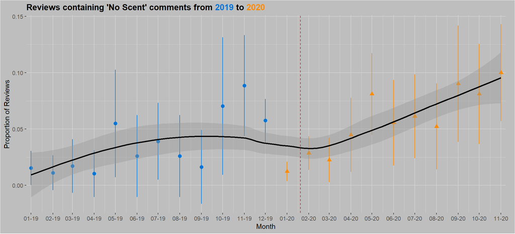

```r
#Creating dataset from scented dataset. New dataset will be for dates after 2018 with quantified unscented phrases in reviews.
cleaned.scented_19_20 = dat.scented %>%
  filter(Date >= as.Date("2019-01-01") & CandleID <= 3) %>%
  mutate(month = lubridate::floor_date(Date, "month")) %>%
  mutate(Review = str_no_scent(Review)) %>%
#Creates year category for graph manipulation and categorization (see below)
  mutate(Year = lubridate::floor_date(Date, "year")) %>%
  mutate(Year = as.factor(Year))

#Graph of new dataset for reviews
ggplot(cleaned.scented_19_20,
       aes(x = month, y = Review)
      ) +
  stat_summary(aes(y = Review, shape = Year, color = Year),  fun.data = mean_cl_normal) +
  scale_x_date(date_breaks = "month",
               date_labels = "%m-%y",
               expand = c(.01,.01),
               limits = c(min(cleaned.scented_19_20$month),
                          max = max(cleaned.scented_19_20$month)
                          ),
               name = "Month"
               ) +
  guides(shape = FALSE) +
  scale_color_manual(values = c("#0074D9", "darkorange"),
                     labels = c("2019", "2020")) +
  scale_y_continuous(name = "Proportion of Reviews") +
  geom_smooth(method = "loess",
              color = "black") +
  geom_vline(xintercept = as.numeric(as.Date("2020-01-20")),
             colour = "red",
             linetype = 2
             ) +
  ggtitle("Reviews containing 'No Scent' comments from <span style='color: #0074D9'>**2019**</span> to <span style='color: darkorange'>**2020**</span>") +
  theme(plot.background = element_rect(fill = "gray"),
        plot.title = element_markdown(face = "bold"),
        axis.text.x = element_text(size = 9),
        legend.position = "none",
        plot.margin = unit(c(.2, .5, .2, .2), "cm"),
        panel.background = element_rect(fill = "gray",
                                colour = "gray",
                                size = 0.5, linetype = "solid"),
        panel.grid.major = element_line(size = 0.5, linetype = 'solid',
                                colour = "lightgray"),
        panel.grid.minor = element_line(size = 0.25, linetype = 'solid',
                                colour = "lightgray")
        )
```